# Yoav data: CDC, cyclin, cell cycle

Kushal K Dey

November 16, 2015

```r
library(qtlcharts)
library(CountClust)
library(parallel)
library(cellcycleR)
library(data.table)
library(binhf)
library(vioplot)
library(limma)
library(readxl)
library(mygene)
library(knitr)
```

## Background

On applying the cellcycleR method on Yoav data across all genes, the cellcycleR seemed to be picking up the ribosomal proteins. Also when these ribosomal proteins were removed, it was picking up heat shock and other genes that are related to cell cycle. In this script, we only focus on genes that are associated with CDC, cyclin and other cell cycle specific activities. This is just to see if CDC and cyclin related genes which should be informative about cell phases are so or not.

## Removing the ribosomal genes

```r
setwd('/Users/kushal/Documents/singleCell-method/project/analysis')
colnames <- colnames(read.table("../data/batch_removed_counts_all_genes.txt"));
molecules_single <- data.frame(fread("../data/batch_removed_counts_all_genes.txt"), row.names = 1);
colnames(molecules_single) <- colnames
cycle_counts_data <- molecules_single;
dim(cycle_counts_data)
```

```
## [1]   578 17084
```

```r
cycle_voom_data <- voom(cycle_counts_data)$E;
cycle_data_norm <- apply(cycle_voom_data,2,function(x)  return (x-mean(x))/sd(x))
celltime_levels <- 100;
cycle_data_norm <- cycle_data_norm[, which(colSums(cycle_data_norm)!=0)]

dim(cycle_data_norm)
```

```
## [1]   578 16860
```

Next we use the **mygene** package to annotate all the genes and save the output as a rda file.

```r
out <- queryMany(colnames(cycle_data_norm),  scopes="ensembl.gene", fields=c("name","summary"), species="human");

query_names <- out$query;
unique_query_names <- unique(query_names);

annotate_genes <- out[match(unique_query_names, query_names),];
save(annotate_genes, file="../rdas/annotate_all_genes.rda")
```

Filtering the CDC and cyclin related genes.

```r
annotate_genes <- get(load("../rdas/annotate_all_genes.rda"));
filter1 <- grep("CDC", annotate_genes$name)
filter2 <- grep("cyclin", annotate_genes$name)
filter3 <- grep("cell cycle", annotate_genes$name)
filter <- unique(c(filter1,filter2, filter3))

annotate_genes_filtered <- annotate_genes[filter,];
gene_names_filtered <- annotate_genes_filtered$query;

labeling_indices <- match(gene_names_filtered, colnames(cycle_data_norm))
cycle_data_norm <- cycle_data_norm[,labeling_indices];
```

The cell phases as assigned using Macosko method

```r
cell_phases <- as.vector(as.matrix(read.table("../data/cell_phase_vector_yoav.txt")));
```

## apply cellcyleR on the cyclin, CDC and cell cycle regulator genes

```r
out <- cell_ordering_class(cycle_data_norm, celltime_levels = 100, num_iter=100, save_path="../rdas/cell_order_ipsc_cdc_cyclin.rda")
```

We ran the method above once already (took around 30 minutes) and now we just load the output.

```r
out <- get(load(file="../rdas/cell_order_ipsc_cdc_cyclin.rda"));
cell_order_full <- cell_ordering_full(out$signal_intensity, dim(cycle_data_norm)[2])
```

We look at the plots of the amplitudes, phases and the non signal variation of the genes.

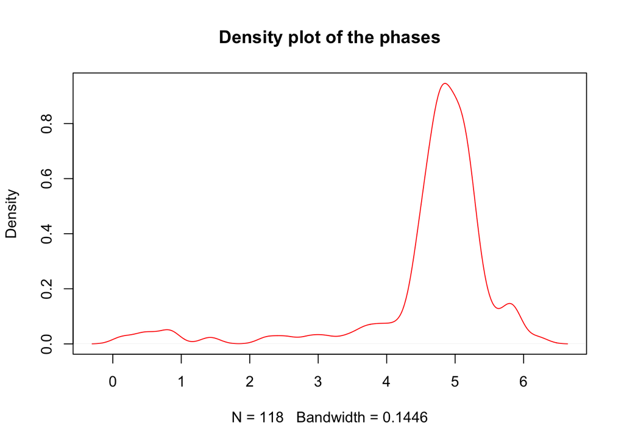

```r
amp_genes <- out$amp;
sd_genes <- out$sigma;
phi_genes <- out$phi;

plot(density(phi_genes), col="red", main="Density plot of the phases")
```

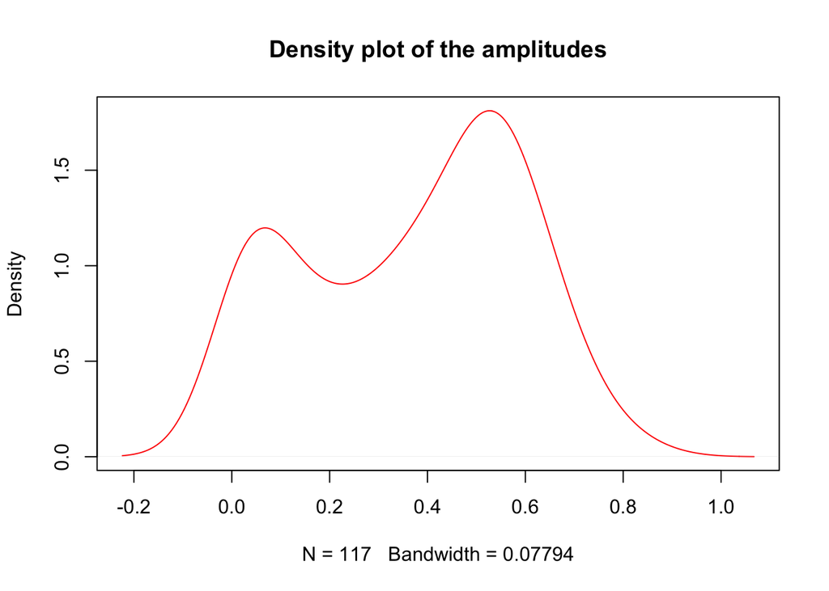

```r
plot(density(amp_genes[-which.max(amp_genes)]), col="red", main="Density plot of the amplitudes")
```

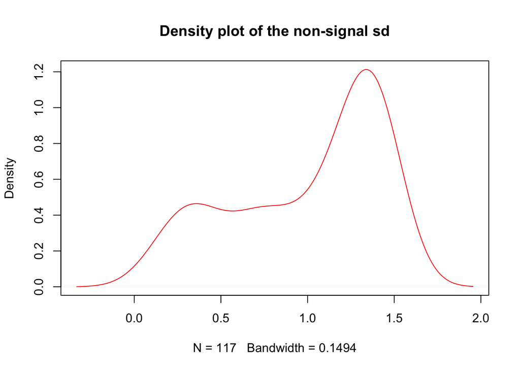

```r
plot(density(sd_genes[-which.max(sd_genes)]), col="red", main="Density plot of the non-signal sd")
```

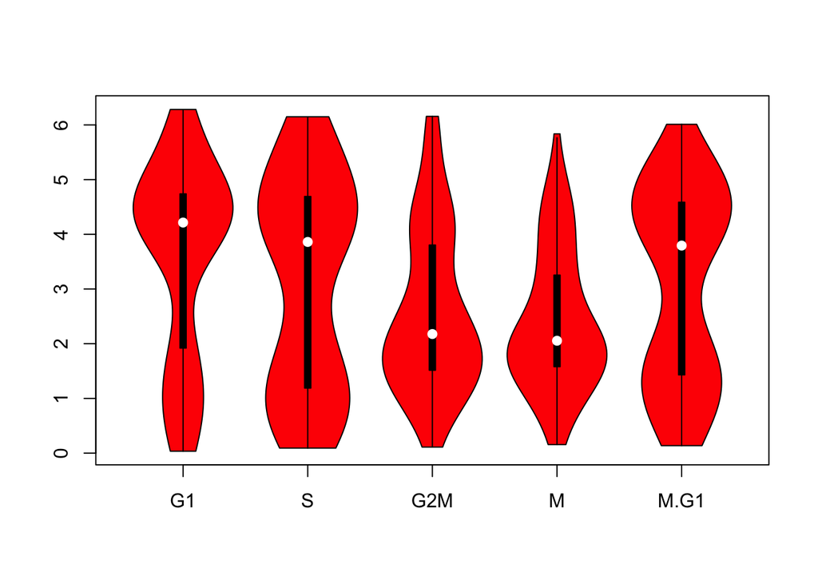

```r
vioplot(cell_order_full[which(cell_phases=="G1.S")],
        cell_order_full[which(cell_phases=="S")],
        cell_order_full[which(cell_phases=="G2.M")],
        cell_order_full[which(cell_phases=="M")],
        cell_order_full[which(cell_phases=="M.G1")],
        names=c("G1","S","G2M","M","M.G1"),
        col="red")
```

We extract the genes with high SNR - these are more likely to be sinusoidal.

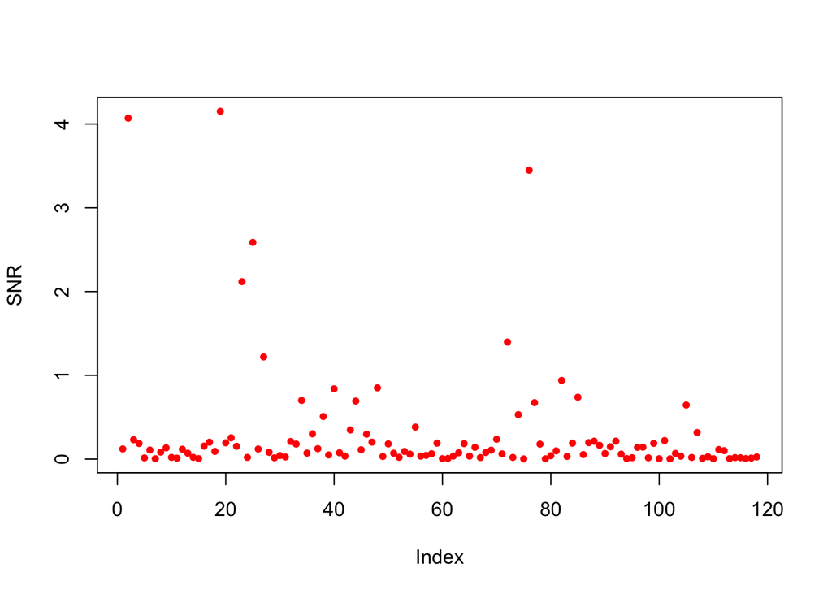

```r
ESS <- amp_genes^2; RSS <- sd_genes^2

SNR <- ESS/RSS;

plot(SNR, col="red", pch=20, lwd=1)
```

```r
top_genes <- which(SNR > 1);
```

Next we plot the qtlcharts for these top sinusoidal genes and see if their patterns are indeed sinusoidal or not.

```r
iplotCurves(t(cycle_data_norm[order(cell_order_full),top_genes]))
```

```
## Set screen size to height=700 x width=1000
```

[interactive chart not shown]

## Gene Annotations

We perform gene annotations on the highly sinusoidal genes obtained from among the non ribosomal genes and see if they have cell phase related functionalities or not.

```r
sinusoidal_gene_names <- colnames(cycle_data_norm);
imp_genes <- sinusoidal_gene_names[order(SNR, decreasing=TRUE)]
top_genes_100 <- imp_genes[1:100];
```

We annotate these genes using the **mygene** package and report them in a tabular format.

```r
out <- queryMany(top_genes_100,  scopes="ensembl.gene", fields=c("name","summary"), species="human");
```

```
## Finished
```

```r
kable(as.data.frame(out))
```

| name | summary | X_id | query |
| --- | --- | --- | --- |
| CDC28 protein kinase regulatory subunit 2 | CKS2 protein binds to the catalytic subunit of the cyclin dependent kinases and is essential for their biological function. The CKS2 mRNA is found to be expressed in different patterns through the cel… | 1164 | ENSG00000123975 |
| CDC28 protein kinase regulatory subunit 1B | CKS1B protein binds to the catalytic subunit of the cyclin dependent kinases and is essential for their biological function. The CKS1B mRNA is found to be expressed in different patterns through the c… | 1163 | ENSG00000173207 |
| cyclin B1 | The protein encoded by this gene is a regulatory protein involved in mitosis. The gene product complexes with p34(cdc2) to form the maturation-promoting factor (MPF). Two alternative transcripts have … | 891 | ENSG00000134057 |
| nuclear casein kinase and cyclin-dependent kinase substrate 1 | This gene encodes a nuclear protein that is highly conserved in vertebrates. The conserved regions of the protein contain several consensus phosphorylation sites for casein kinase II and cyclin-depend… | 64710 | ENSG00000069275 |
| calcyclin binding protein | The protein encoded by this gene is a calcyclin binding protein. It may be involved in calcium-dependent ubiquitination and subsequent proteosomal degradation of target proteins. It probably serves as… | 27101 | ENSG00000116161 |
| cyclin I | The protein encoded by this gene belongs to the highly conserved cyclin family, whose members are characterized by a dramatic periodicity in protein abundance through the cell cycle. Cyclins function … | 10983 | ENSG00000118816 |
| cyclin-dependent kinase 1 | The protein encoded by this gene is a member of the Ser/Thr protein kinase family. This protein is a catalytic subunit of the highly conserved protein kinase complex known as M-phase promoting factor … | 983 | ENSG00000170312 |
| cyclin G1 | The eukaryotic cell cycle is governed by cyclin-dependent protein kinases (CDKs) whose activities are regulated by cyclins and CDK inhibitors. The protein encoded by this gene is a member of the cycli… | 900 | ENSG00000113328 |
| cyclin B2 | Cyclin B2 is a member of the cyclin family, specifically the B-type cyclins. The B-type cyclins, B1 and B2, associate with p34cdc2 and are essential components of the cell cycle regulatory machinery. … | 9133 | ENSG00000157456 |
| cyclin-dependent kinase 2 associated protein 1 | The protein encoded by this gene is a cyclin-dependent kinase 2 (CDK2) -associated protein which is thought to negatively regulate CDK2 activity by sequestering monomeric CDK2, and targeting CDK2 for … | 8099 | ENSG00000111328 |
| cyclin C | The protein encoded by this gene is a member of the cyclin family of proteins. The encoded protein interacts with cyclin-dependent kinase 8 and induces the phophorylation of the carboxy-terminal domai… | 892 | ENSG00000112237 |
| cyclin D2 | The protein encoded by this gene belongs to the highly conserved cyclin family, whose members are characterized by a dramatic periodicity in protein abundance through the cell cycle. Cyclins function … | 894 | ENSG00000118971 |
| cyclin-dependent kinase inhibitor 3 | The protein encoded by this gene belongs to the dual specificity protein phosphatase family. It was identified as a cyclin-dependent kinase inhibitor, and has been shown to interact with, and dephosph… | 1033 | ENSG00000100526 |
| cyclin-dependent kinase 7 | The protein encoded by this gene is a member of the cyclin-dependent protein kinase (CDK) family. CDK family members are highly similar to the gene products of Saccharomyces cerevisiae cdc28, and Schi… | 1022 | ENSG00000134058 |
| cell cycle associated protein 1 | NA | 4076 | ENSG00000135387 |
| cyclin A2 | The protein encoded by this gene belongs to the highly conserved cyclin family, whose members are characterized by a dramatic periodicity in protein abundance through the cell cycle. Cyclins function … | 890 | ENSG00000145386 |
| cyclin-dependent kinase 4 | The protein encoded by this gene is a member of the Ser/Thr protein kinase family. This protein is highly similar to the gene products of S. cerevisiae cdc28 and S. pombe cdc2. It is a catalytic subun… | 1019 | ENSG00000135446 |
| cyclin-dependent kinase 12 | NA | 51755 | ENSG00000167258 |
| cyclin B1 interacting protein 1, E3 ubiquitin protein ligase | HEI10 is a member of the E3 ubiquitin ligase family and functions in progression of the cell cycle through G(2)/M. | 57820 | ENSG00000100814 |
| CWF19-like 2, cell cycle control (S. pombe) | NA | 143884 | ENSG00000152404 |
| cyclin T1 | This gene encodes a member of the highly conserved cyclin C subfamily. The encoded protein tightly associates with cyclin-dependent kinase 9, and is a major subunit of positive transcription elongatio… | 904 | ENSG00000129315 |
| cyclin-dependent kinase 2 interacting protein | The protein encoded by this gene is reported to be a component of the DNA replication complex as well as a genome-maintenance protein. It may interact with proteins important for replication initiatio… | 51550 | ENSG00000100865 |
| cyclin-dependent kinase 11B | This gene encodes a member of the serine/threonine protein kinase family. Members of this kinase family are known to be essential for eukaryotic cell cycle control. Due to a segmental duplication, thi… | 984 | ENSG00000248333 |
| cyclin L1 | NA | 57018 | ENSG00000163660 |
| CDC-like kinase 2 | This gene encodes a dual specificity protein kinase that phosphorylates serine/threonine and tyrosine-containing substrates. Activity of this protein regulates serine- and arginine-rich (SR) proteins … | 1196 | ENSG00000176444 |
| zyg-11 family member B, cell cycle regulator | NA | 79699 | ENSG00000162378 |
| runt-related transcription factor 1; translocated to, 1 (cyclin D-related) | This gene encodes a member of the myeloid translocation gene family which interact with DNA-bound transcription factors and recruit a range of corepressors to facilitate transcriptional repression. Th… | 862 | ENSG00000079102 |
| cyclin D binding myb-like transcription factor 1 | This gene encodes a transcription factor that contains a cyclin D-binding domain, three central Myb-like repeats, and two flanking acidic transactivation domains at the N- and C-termini. The encoded p… | 9988 | ENSG00000135164 |
| cyclin-dependent kinase 2 associated protein 2 | This gene encodes a protein that interacts with cyclin-dependent kinase 2 associated protein 1. Pseudogenes associated with this gene are located on chromosomes 7 and 9. Alternatively spliced transcri… | 10263 | ENSG00000167797 |
| cyclin D-type binding-protein 1 | This gene was identified by the interaction of its gene product with Grap2, a leukocyte-specific adaptor protein important for immune cell signaling. The protein encoded by this gene was shown to inte… | 23582 | ENSG00000166946 |

[output cut: 70 more lines]